# Digit Recognizer Image Analysis

## Library Includes

```r
library(tidyverse)      # General utility packages
library(keras)          # Used for deep learning
```

## Preparing the Data

The MNIST dataset is included with Keras and can be accessed using the `dataset_mnist()` function. Here we load the dataset then create variables for our test and training data:

```r
mnist <- dataset_mnist()
x_train <- mnist$train$x
y_train <- mnist$train$y
x_test <- mnist$test$x
y_test <- mnist$test$y
```

The x data is a 3-d array `(images,width,height)` of grayscale values . To prepare the data for training we convert the 3-d arrays into matrices by reshaping width and height into a single dimension (28x28 images are flattened into length 784 vectors). Then, we convert the grayscale values from integers ranging between 0 to 255 into floating point values ranging between 0 and 1:

```r
# reshape
x_train <- array_reshape(x_train, c(nrow(x_train), 784))
x_test <- array_reshape(x_test, c(nrow(x_test), 784))
# rescale
x_train <- x_train / 255
x_test <- x_test / 255
```

Note that we use the `array_reshape()` function rather than the `dim<-()` function to reshape the array. This is so that the data is re-interpreted using row-major semantics (as opposed to R’s default column-major semantics), which is in turn compatible with the way that the numerical libraries called by Keras interpret array dimensions.

The y data is an integer vector with values ranging from 0 to 9. To prepare this data for training we one-hot encode the vectors into binary class matrices using the Keras `to_categorical()` function:

```r
y_train <- to_categorical(y_train, 10)
y_test <- to_categorical(y_test, 10)
```

## Defining the Model

The core data structure of Keras is a model, a way to organize layers. The simplest type of model is the Sequential model, a linear stack of layers.

We begin by creating a sequential model and then adding layers using the pipe (`%>%`) operator:

```r
model <- keras_model_sequential()
model %>%
  layer_dense(units = 256, activation = 'relu', input_shape = c(784)) %>%
  layer_dropout(rate = 0.4) %>%
  layer_dense(units = 128, activation = 'relu') %>%
  layer_dropout(rate = 0.3) %>%
  layer_dense(units = 10, activation = 'softmax')
```

The `input_shape` argument to the first layer specifies the shape of the input data (a length 784 numeric vector representing a grayscale image). The final layer outputs a length 10 numeric vector (probabilities for each digit) using a [softmax activation function](https://en.wikipedia.org/wiki/Softmax_function).

Use the [`summary()`](https://rdrr.io/r/base/summary.html) function to print the details of the model:

```r
summary(model)
```

```
Model: "sequential_3"
________________________________________________________________________________________________________________________________________
Layer (type)                                                 Output Shape                                          Param #
========================================================================================================================================
dense_11 (Dense)                                             (None, 256)                                           200960
________________________________________________________________________________________________________________________________________
dropout_7 (Dropout)                                          (None, 256)                                           0
________________________________________________________________________________________________________________________________________
dense_10 (Dense)                                             (None, 128)                                           32896
________________________________________________________________________________________________________________________________________
dropout_6 (Dropout)                                          (None, 128)                                           0
________________________________________________________________________________________________________________________________________
dense_9 (Dense)                                              (None, 10)                                            1290
========================================================================================================================================
Total params: 235,146
Trainable params: 235,146
Non-trainable params: 0
________________________________________________________________________________________________________________________________________
```

Next, compile the model with appropriate loss function, optimizer, and metrics:

```r
model %>% compile(
  loss = 'categorical_crossentropy',
  optimizer = optimizer_rmsprop(),
  metrics = c('accuracy')
)
```

## Training and Evaluation

Use the [`fit()`](https://tensorflow.rstudio.com/keras/reference/reexports.html) function to train the model for 30 epochs using batches of 128 images:

```r
history <- model %>% fit(
  x_train, y_train,
  epochs = 30, batch_size = 128,
  validation_split = 0.2
)
```

The `history` object returned by [`fit()`](https://tensorflow.rstudio.com/keras/reference/reexports.html) includes loss and accuracy metrics which we can plot:

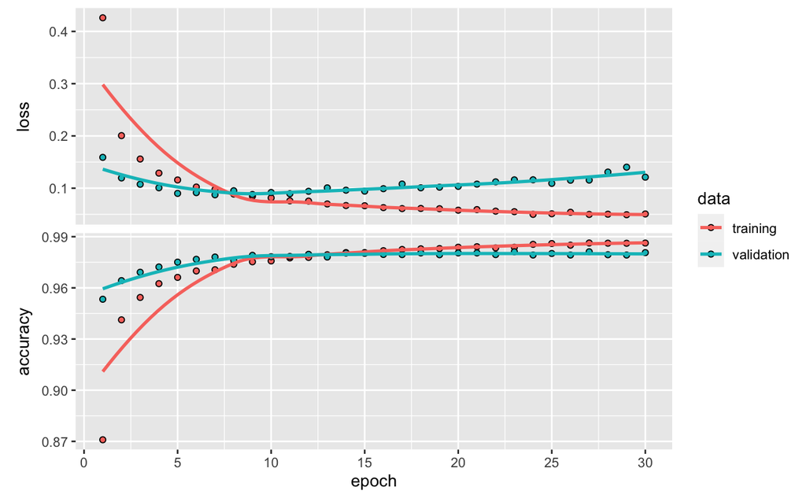

```r
plot(history)
```

Evaluate the model’s performance on the test data:

```r
model %>% evaluate(x_test, y_test)
```

```
     loss  accuracy
0.1145261 0.9801000
```

Generate predictions on new data:

```r
predictions <- k_argmax(predict(model, x_test), axis=-1) %>% k_eval()
class(predictions)
```

```
[1] "array"
```

```r
predictions
```

[output not shown]